# Women Basketball project for impact load and biomarkers

Author

Statistical Consulting Services

**Report Acknowledgment**

[figure not shown]

This report was generated by the University of Connecticut’s Statistical Consulting Services (SCS). For any questions regarding the analysis or findings, please contact the consultant assigned to this project, Shrijana Gautam, or the SCS Director, Dr. Timothy Moore. More information on the SCS can be found at statsconsulting.uconn.edu

[figure not shown]

**Introduction**

The University of Connecticut (UConn) Women’s Basketball (WBB) team is one of the most competitive team in the United Statesand has won a total of 12 NCAA Division I national championships. The physical demands of players are characterized by high-intensity movements, frequent directional changes, and rigorous training schedules that place significant stress on athletes’ musculoskeletal and physiological systems. Monitoring biomarkers of cartilage turnover and inflammation can offer valuable insights into how athletes respond to these demands over time. In particular, biomarkers such as C2C (collagen type II cleavage), CPII (procollagen II carboxy propeptide), and CS836 (aggrecan chondroitin sulfate 846 epitope) are increasingly recognized for their ability to reflect cartilage degradation and synthesis, and may serve as indicators of physiological stress, injury risk, or recovery.

This study leverages longitudinal data collected from UConn Women’s Basketball players during the 2022–2023 season to investigate changes in the biomarkers across different phases of the athletic year. Data were collected at six key time points— off-season, pre-season, regular season, mid-season, NCAA, and post-season providing a comprehensive view of the athletes’ physiological status across a full competitive cycle. In addition to biomarker data, cumulative mechanical impact load for the week preceding each measurement was recorded, enabling analysis of the relationship between physical stress and biochemical responses.

The overarching goal of this study was to examine the changes in inflammation-related biomarkers over time in women’s basketball players and to assess the impact of injury on load metrics. Specifically, this study will evaluate whether impact load change from pre- to post-injury, how biomarkers fluctuate across the season, and whether biomarker correlations shift over time. Additionally, I will assess the relationship between biomarker levels and cumulative impact load from the preceding week. These findings may help identify injury risk indicators and improve prevention strategies in female basketball athletes.

**Objectives**

The objective of this study is to examine the temporal dynamics of inflammation-related biomarkers and their association with physical load in a cohort of WBB players. Specifically, the study aims to:

1. Evaluate whether impact load changes significantly from pre- to post-injury
2. Assess whether biomarker levels vary significantly across different periods of the competitive season
3. Investigate the correlations among biomarkers and whether these relationships change over the course of the season
4. Determine whether biomarker values are associated with cumulative impact loads from the week preceding measurement

**Methods**

Longitudinal data across six key time points— off-season, pre-season, regular season, mid-season, NCAA, and post-season six time points was collected from 11 WBB athletes for this study. Biomarkers of interest: C2C, CPII, and CS836 were measured at each time point, along with the cumulative impact load in the one-week period preceding the measurement. Given the repeated-measures design and small sample size, I employed Linear Mixed-Effects Models (LMMs; Bates et al., 2015) using the lme4 package and lmerTest package (Kuznetsova et al., 2017) in R (R version 4.4.3) to appropriately account for both fixed effects (time point, injury status) and random effects (athlete-specific variability). This model was used because it is well-suited for unbalanced and incomplete longitudinal data.

To assess whether cumulative impact load significantly differs for pre- and post-injury periods, an LMM was constructed with injury status (pre vs. post) as a fixed effect, accounting for repeated observations from the same individual. To evaluate whether biomarkers change significantly over the season, biomarker type and time point were included as fixed effects, and athlete ID as a random effect, enabling joint modeling of repeated, multi-category responses. Relationships between biomarkers (e.g., C2C vs. CPII) were analyzed using Repeated Measures Correlation (rmcorr), a method that adjusts for intra-individual correlation. To determine whether these associations vary across the season, interaction terms between biomarker values and time points were included in an LMM framework. Finally, to test the association between cumulative impact load and biomarker levels, we modeled biomarker value as the outcome and one-week prior impact load as a continuous fixed effect, again accounting for within-athlete dependencies using random intercepts.For model selection, the Likelihood Ratio Test (LRT) was used to compare the goodness-of-fit.

For my data analysis, I used several R packages. I used ggplot2 to make elegant and clear plots (Wickham, 2016). I used lme4 to fit linear mixed-effects models (Bates et al., 2015). I used lmerTest to run tests in these models (Kuznetsova et al., 2017). For data manipulation, I used dplyr (Wickham et al., 2023) and tidyr (Wickham, Vaughan, & Girlich, 2024). These packages are part of the tidyverse (Wickham et al., 2019). I used gtsummary to create summary tables (Sjoberg et al., 2021). I used janitor to clean my data (Firke, 2024). I used rmcorr to study repeated measures correlation (Bakdash & Marusich, 2024). I used cowplot to improve and annotate my plots (Wilke, 2024). I used sjPlot to make social science visualizations (Lüdecke, 2024).

**Results & Conclusions**

**Descriptive Analysis**

```r
library(readxl)
library(dplyr)
library(tidyr)
library(gtsummary)
library(ggplot2)
library(janitor)
library(tidyverse)
library(lme4)
library(lmerTest)

biomarker <- read_excel("Copy of burland_data_WBB study3.18.xlsx",
                        sheet = "biomarker")

injury <- read_excel("Copy of burland_data_WBB study3.18.xlsx",
                     sheet = "injury")


demographics <- read_excel("Copy of burland_data_WBB study3.18.xlsx",
                           sheet = "demographics")

impact <- read_excel("Copy of burland_data_WBB study3.18.xlsx",
                     sheet = "impact load metrics")

pre_post <- read_excel("Copy of burland_data_WBB study3.18.xlsx",
                                                 sheet = "injury_pre_post")


df_wide1 <- biomarker %>%
  pivot_wider(names_from = biomarker, values_from = value)
```

The table summarizes data for 11 female basketball athletes, with an average age of 20.54 years (±1.96, range 18-24), height of 1.86 m (±0.067, range 1.75-1.95), and mass of 82 kg (±10.32, range 67.57–101.13). Biomarker levels include C2C (cartilage breakdown) at 114 ng/ml (±20), CPII (cartilage synthesis) at 790 ng/ml (±200), and CS836 (joint inflammation) at 27 ng/ml (±37). Season impact loads are slightly higher on the left (33,649.52 ± 9,754.61) than the right (32,766.58 ± 8,385.23), with step counts nearly equal (left: 2,557.62 ± 473.57; right: 2,559.59 ± 465.21).

Table 1. Participant demographics and study information for UConn Women’s Basketball team (2022-2023).

| **Outcome** | **Collegiate Female Basketball Athletes (n=11)** |
| --- | --- |
| Age, year | 20.54 ± 1.96 (18-24) |
| Height, m | 1.86 ± 0.067 (1.75-1.95) |
| Mass, kg | 82 ± 10.32 (67.57 – 101.13) |
| **Biomarker** |  |
| C2C level, ng/ml | 114 ± 20 |
| CPII level, ng/ml | 790 ± 200 |
| CS836 level, ng/ml | 27 ± 37 |
| **Season impact load** |  |
| Left | 33,649.52 ± 9,754.61 |
| Right | 32,766.58 ± 8,385.23 |
| **Step Count (no. steps)** |  |
| Left | 2,557.62 ± 473.57 |
| Right | 2,559.59 ± 465.21 |

The Figure 1 displays a bar plot illustrating the number of injuries by location among athletes. The right ankle was the most commonly injured site, with 8 reported cases, followed by the left ankle with 6 injuries and the right knee with 5 injuries. Injuries to the left hip and left knee were much less frequent, with only 1 case each. Overall, ankle injuries (both left and right) accounted for the majority of injury occurrences, highlighting a potential area of concern for prevention efforts.

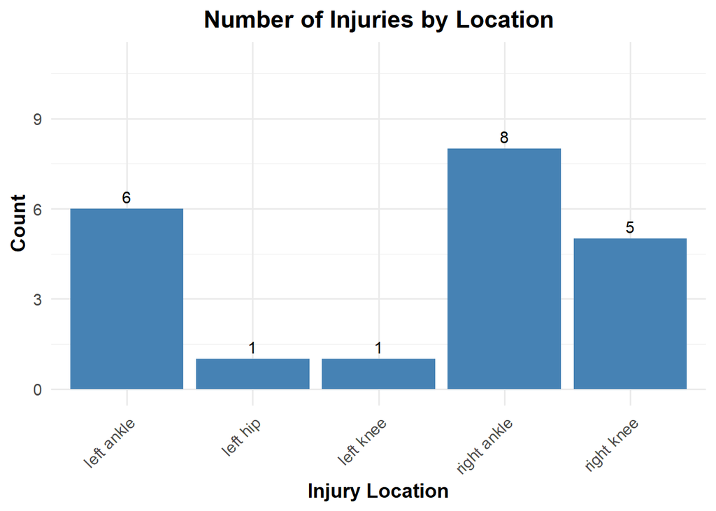

```r
# Plot number of injuries by location
ggplot(injury, aes(x = injury_location)) +
  geom_bar(fill = "steelblue") +
  geom_text(stat = "count", aes(label = ..count..), vjust = -0.5, size = 4) +
  theme_minimal(base_size = 14) +
  theme(
    axis.text.x = element_text(angle = 45, hjust = 1),
    plot.title = element_text(face = "bold", hjust = 0.5),
    axis.title.x = element_text(face = "bold"),
    axis.title.y = element_text(face = "bold")
  ) +
  labs(
    title = "Number of Injuries by Location",
    x = "Injury Location",
    y = "Count"
  ) +
  ylim(0, max(table(injury$injury_location)) + 3)
```

Figure 1: Frequency of injuries by body location among UConn Women’s Basketball team athletes.

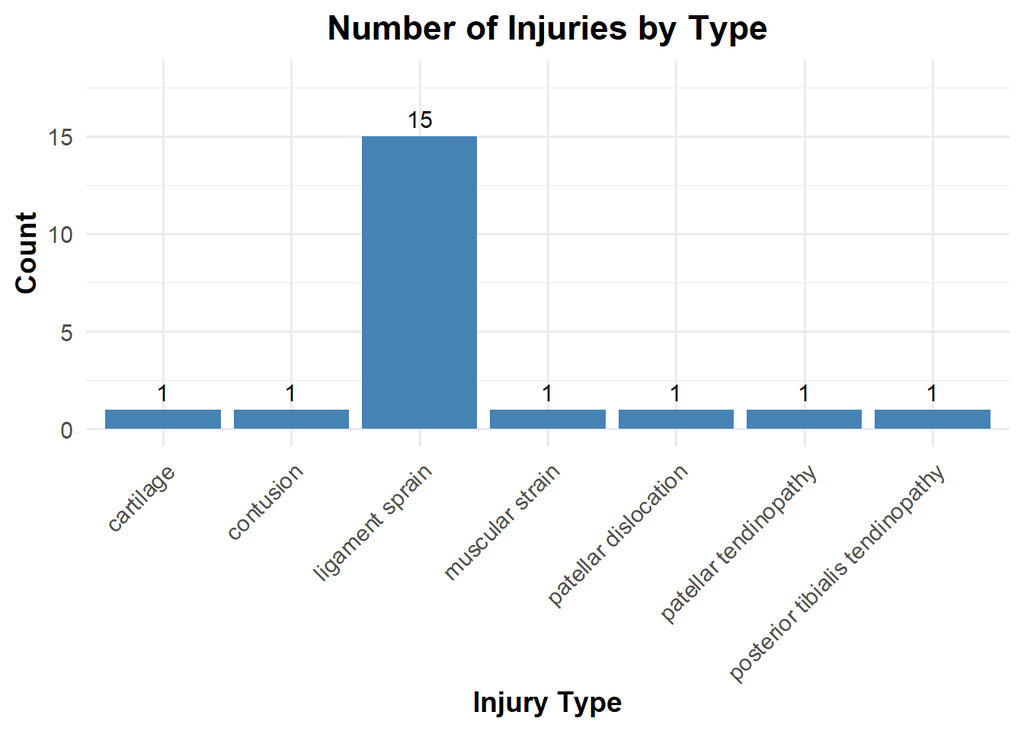

```r
# Plot the number of injuries by type
ggplot(injury, aes(x = injury_type)) +
  geom_bar(fill = "steelblue") +
  geom_text(stat = "count", aes(label = ..count..), vjust = -0.5, size = 4) +
  theme_minimal(base_size = 14) +
  theme(
    axis.text.x = element_text(angle = 45, hjust = 1),
    plot.title = element_text(face = "bold", hjust = 0.5),
    axis.title.x = element_text(face = "bold"),
    axis.title.y = element_text(face = "bold")
  ) +
  labs(
    title = "Number of Injuries by Type",
    x = "Injury Type",
    y = "Count"
  ) +
  ylim(0, max(table(injury$injury_type)) + 3)
```

Figure 2: Number of injuries by type UConn Women’s Basketball team athletes.

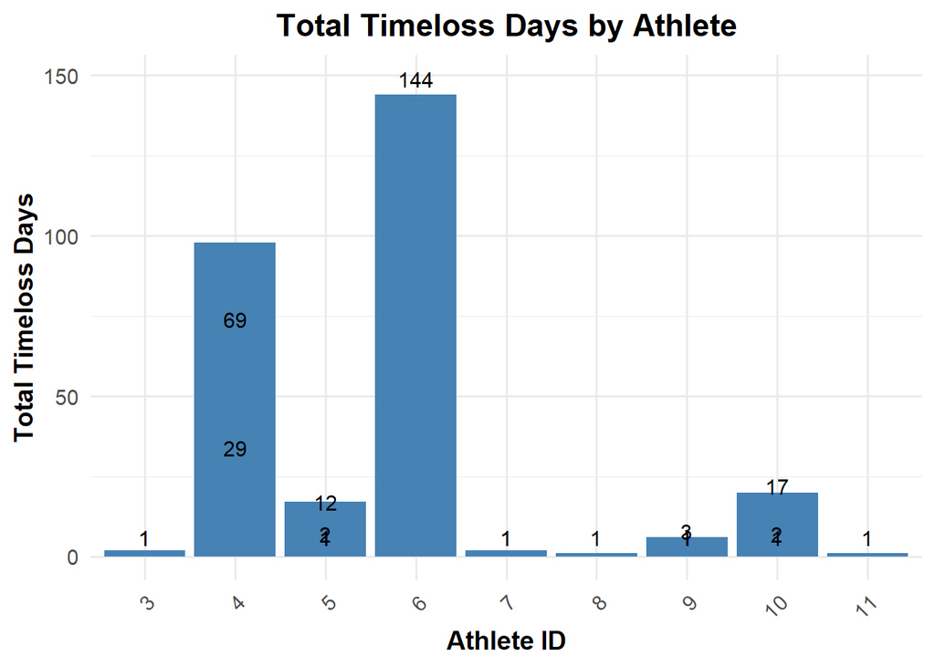

```r
# Plot total timeloss days by athlete
ggplot(injury, aes(x = as.factor(athelete_id), y = timeloss_days)) +
  geom_bar(stat = "identity", fill = "steelblue") +
  geom_text(aes(label = timeloss_days), vjust = -0.5, size = 4) +
  theme_minimal(base_size = 14) +
  theme(
    axis.text.x = element_text(angle = 45, hjust = 1),
    plot.title = element_text(face = "bold", hjust = 0.5),
    axis.title.x = element_text(face = "bold"),
    axis.title.y = element_text(face = "bold")
  ) +
  labs(
    title = "Total Timeloss Days by Athlete",
    x = "Athlete ID",
    y = "Total Timeloss Days"
  ) +
  ylim(0, max(injury$timeloss_days, na.rm = TRUE) + 5)
```

Figure 3: Total timeloss days by athlete due to injuries for each WBB athlete.

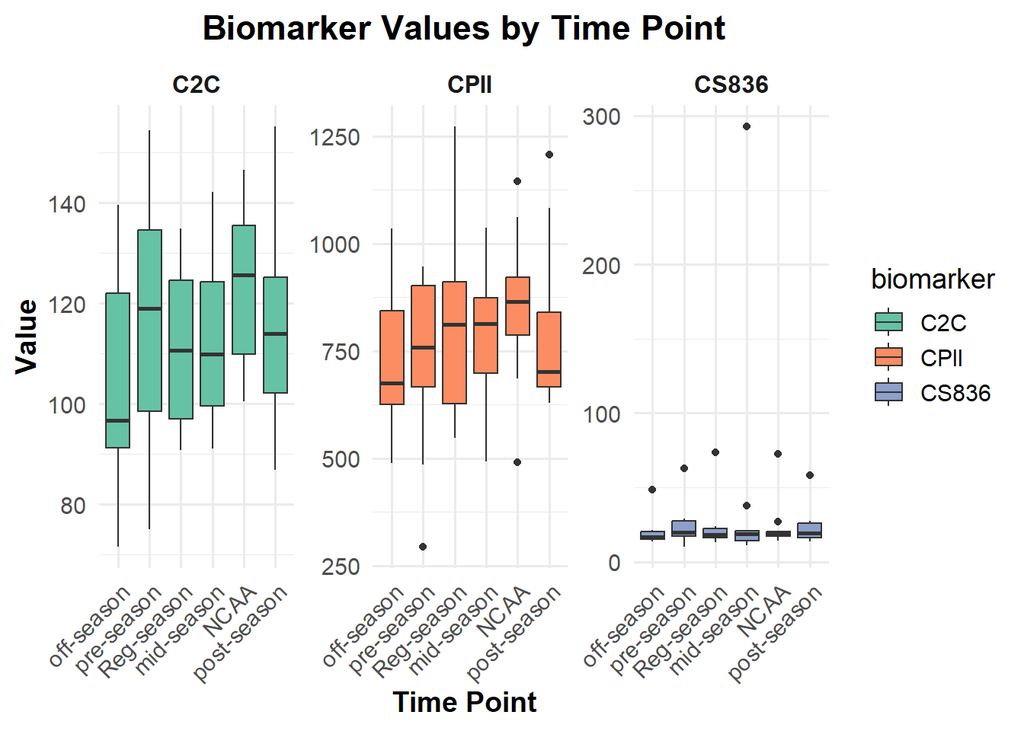

```r
# Boxplot of biomarker values by time point
biomarker$time_point <- factor(biomarker$time_point, levels = c(
  "off-season", "pre-season", "Reg-season", "mid-season", "NCAA", "post-season"
))

ggplot(biomarker, aes(x = time_point, y = value, fill = biomarker)) +
  geom_boxplot() +
  facet_wrap(~ biomarker, scales = "free_y") +  #
  scale_fill_brewer(palette = "Set2") +
  theme_minimal(base_size = 14) +
  theme(
    axis.text.x = element_text(angle = 45, hjust = 1),
    plot.title = element_text(face = "bold", hjust = 0.5),
    axis.title.x = element_text(face = "bold"),
    axis.title.y = element_text(face = "bold"),
    strip.text = element_text(face = "bold", size = 12)  # Make facet labels bold
  ) +
  labs(
    title = "Biomarker Values by Time Point",
    x = "Time Point",
    y = "Value"
  )
```

Figure 4: Biomarker values by time point measured across six different time points in the athletic season.

**Inferential Analysis**

Objective a. Does impact load change significantly from pre to post injury?

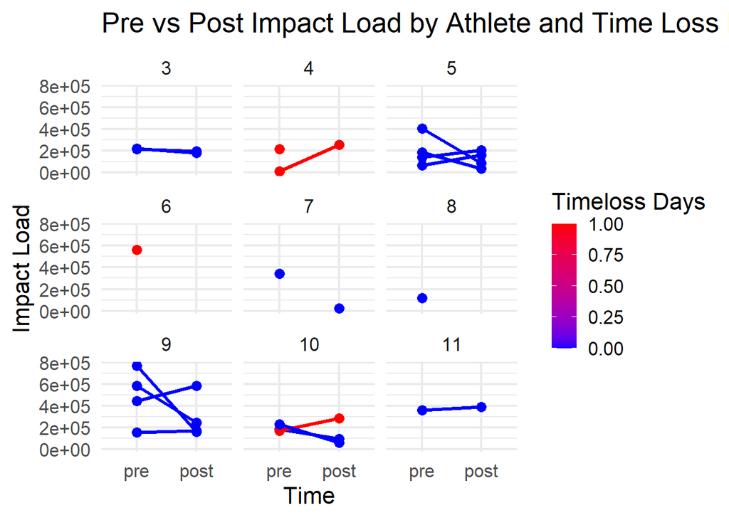

```r
df_long <- pre_post %>%
  pivot_longer(cols = c(pre_impact_load, post_impact_load),
               names_to = "time",
               values_to = "impact_load") %>%
  mutate(
    time = recode(time,
                  pre_impact_load = "pre",
                  post_impact_load = "post"),
    time = factor(time, levels = c("pre", "post"))
  ) %>% drop_na(impact_load)

df_long$timeloss_week <- ifelse(df_long$timeloss_days>7, 1, 0)

ggplot(df_long, aes(x = time, y = impact_load,
                    group = interaction(athelete_id, date),
                    color = timeloss_week)) +
  geom_line(lwd = 1.2) +
  geom_point(size = 3) +
  scale_color_gradient(low = "blue", high = "red") +
  theme_minimal(base_size = 16) +
  labs(
    title = "Pre vs Post Impact Load by Athlete and Time Loss Days",
    x = "Time", y = "Impact Load",
    color = "Timeloss Days"
  ) + facet_wrap(~athelete_id)
```

Figure 5: Pre vs post impact load by athlete and time loss days.

```r
df_long$impact_load_scaled <- scale(df_long$impact_load)
model1 <- lmer(impact_load_scaled ~ time  + (1 | athelete_id), data = df_long)


library(sjPlot)
tab_model(model1, show.re.var = FALSE )
```

|  | impact load scaled |  |  |
| --- | --- | --- | --- |
| Predictors | Estimates | CI | p |
| (Intercept) | 0.23 | -0.31 – 0.77 | 0.401 |
| time [post] | -0.50 | -1.09 – 0.10 | 0.097 |
| ICC | 0.26 |  |  |
| N <sub>athelete_id</sub> | 9 |  |  |
| Observations | 35 |  |  |
| Marginal R<sup>2</sup> / Conditional R<sup>2</sup> | 0.061 / 0.302 |  |  |

The linear mixed-effects model suggests that impact load tends to decrease following injury among WBB players, with an average reduction of 0.50 standard deviations at the post-injury time point compared to pre-injury.

While this change is not statistically significant at the conventional 0.05 level (p = 0.097), it suggests a trend toward reduced physical load following injury. Given the small sample size and repeated measures, this finding should be interpreted with caution but may still be clinically meaningful.

```r
model1 <- lmer(impact_load_scaled ~ time * timeloss_week + (1 | athelete_id), data = df_long, REML = FALSE)
model2 <- lmer(impact_load_scaled ~ time + timeloss_week + (1 | athelete_id), data = df_long, REML = FALSE)

anova(model2, model1)
```

[output not shown]

2. Do biomarkers change significantly over periods of the season?

I ran Linear Mixed-Effects Models to see if the values of each biomarker changed significantly across different parts of the season, using pre-season as the reference group. Each model includes a random effect for athlete ID to account for repeated measures from the same player.

```r
summary_df <- biomarker %>%
  group_by(time_point, biomarker) %>%
  summarise(
    mean_value = mean(value, na.rm = TRUE),
    se = sd(value, na.rm = TRUE) / sqrt(n())
  )
summary_df <- summary_df %>%
  mutate(time_point = factor(time_point, levels = c(
    "off-season", "pre-season", "Reg-season", "mid-season", "NCAA", "post-season"
  )))
```

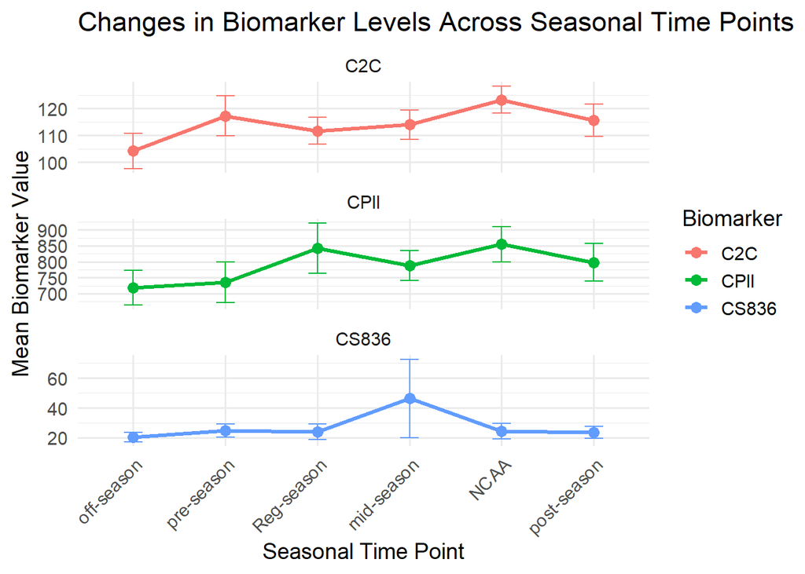

```r
library(cowplot)
ggplot(summary_df, aes(x = time_point, y = mean_value, color = biomarker, group = biomarker)) +
  geom_line(size = 1.2) +
  geom_point(size = 3) +
  geom_errorbar(aes(ymin = mean_value - se, ymax = mean_value + se), width = 0.2) +
  labs(
    title = "Changes in Biomarker Levels Across Seasonal Time Points",
    x = "Seasonal Time Point",
    y = "Mean Biomarker Value",
    color = "Biomarker"
  ) +
  theme_minimal(base_size = 14) +
  facet_wrap(~biomarker, scales = "free_y", ncol = 1)+
  theme(axis.text.x = element_text(angle = 45, hjust = 1))
```

Figure 6: Changes in Biomarker Levels Across Seasonal Time Points

```r
biomarker$time_point.f <- factor(biomarker$time_point,
                                 levels = unique(biomarker$time_point),
                                 ordered = F)
biomarker$time_point.f <-relevel(biomarker$time_point.f,
                                 ref = "pre-season")

biomarker_df <- biomarker %>%
  mutate(time_point = factor(time_point, levels = c(
    "off-season", "pre-season", "Reg-season", "mid-season", "NCAA", "post-season"
  )))


m1.ri <- lmer( value ~ time_point.f + (1 | athlete_id),
           data = biomarker_df %>% filter(biomarker=="CPII"))
m1.ri2 <- lmer(value ~ time_point.f + (1|athlete_id),
              data = biomarker_df %>% filter(biomarker=="C2C"))
m1.ri3 <- lmer(value ~ time_point.f + (1|athlete_id),
               data = biomarker_df %>%
                 filter(biomarker=="CS836" &
                        value < 250))
library(sjPlot)
tab_model( m1.ri, m1.ri2, m1.ri3,
          dv.labels = c("CPII",
                        "CS836",
                        "C2C"),  show.re.var = FALSE)
```

[output not shown]

3. Are the biomarkers significantly correlated and do these relationships change over the season?

```r
library(rmcorr)


df_wide1 <- biomarker %>%
  pivot_wider(names_from = biomarker, values_from = value)

rmcorr(participant = athlete_id, measure1 = C2C, measure2 = CPII, dataset = df_wide1)
rmcorr(participant = athlete_id, measure1 = CS836, measure2 = CPII, dataset = df_wide1)
rmcorr(participant = athlete_id, measure1 = C2C, measure2 = CS836, dataset = df_wide1)
```

[output not shown]

The Table 2 presents the repeated measures correlation (r_rm), p-values, and 95% confidence intervals (CI) for three biomarker pairs: C2C vs. CPII, CS836 vs. CPII, and C2C vs. CS836. In all three cases, the p-values are greater than 0.05, and the 95% confidence intervals include zero, indicating that the correlations are not statistically significant.

Table 2: Summary table for correlation between biomarkers (across all time points).

| Biomarker Pair | r_rm (Repeated Measures Correlation) | p-value | 95% CI | Conclusion |
| --- | --- | --- | --- | --- |
| C2C vs. CPII | 0.128 | 0.377 | [-0.156, 0.392] | Not statistically significant |
| CS836 vs. CPII | -0.157 | 0.278 | [-0.417, 0.127] | Not statistically significant |
| C2C vs. CS836 | -0.050 | 0.731 | [-0.324, 0.232] | Not statistically significant |

```r
model1 <- lmer(CPII ~ C2C  + time_point + (1 | athlete_id), data = df_wide1)
summary(model1)
car::Anova(model1, type = "III")

model2 <- lmer(CPII ~ CS836 + time_point + (1 | athlete_id), data = df_wide1)
summary(model2)
car::Anova(model2, type = "III")

model3 <- lmer(CS836 ~ C2C + time_point + (1 | athlete_id), data = df_wide1)
summary(model3)
car::Anova(model3, type = "III")
```

[output not shown]

```r
#to compare which model is best (interaction or without interaction)
model11 <- lmer(CPII ~ C2C  * time_point + (1 | athlete_id), data = df_wide1)
anova(model1, model11)

model22 <- lmer(CPII ~ CS836  * time_point + (1 | athlete_id), data = df_wide1)
anova(model2, model22)

model33 <- lmer(CS836 ~ C2C * time_point + (1 | athlete_id), data = df_wide1)
anova(model3, model33)
```

[output not shown]

To compare either simple model or interaction model is best, I used likelihood ratio test. In all case p-value > 0.05, which means interaction does not add much value so simple model is used for this analysis using 5 % level of significant.

Table 3 summarizes models without interaction terms, examining relationships between different biomarker pairs. In Model 1, C2C was significantly positively associated with CPII (Estimate = 3.22, p = 0.037), suggesting that higher levels of C2C correspond to higher levels of CPII. In contrast, Model 2 showed no significant association between CS836 and CPII (p = 0.310), and Model 3 also indicated no significant relationship between C2C and CS836 (p = 0.919).

Table 3: This is a summary table for Models Without Interaction Terms.

| Model | Predictor Biomarker | Outcome Biomarker | Estimate | p-value | Interpretation |
| --- | --- | --- | --- | --- | --- |
| model1 | C2C | CPII | 3.22 | 0.037 | Significant positive relationship |
| model2 | CS836 | CPII | -0.76 | 0.310 | Not significant |
| model3 | C2C | CS836 | 0.031 | 0.919 | Not significant |

```r
df_wide1 <- df_wide1 %>%
  mutate(time_point = factor(time_point, levels = c(
    "off-season", "pre-season", "Reg-season", "mid-season", "NCAA", "post-season"
  )))
```

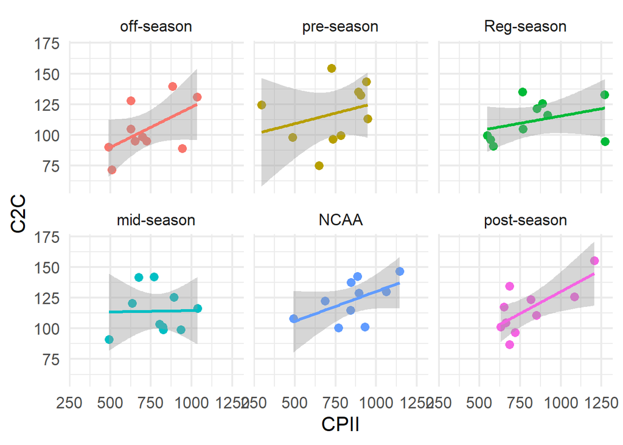

```r
ggplot(df_wide1, aes(x = CPII, y = C2C, color = time_point)) +
  geom_point(size = 3) +
  geom_smooth(method = "lm", se = TRUE, size = 1.1) +
  facet_wrap(~time_point)+
  theme_minimal(base_size = 16)+
  theme(legend.position = "none")
```

Figure 7: comparing two biomarkers C2C and CPII by different time points.

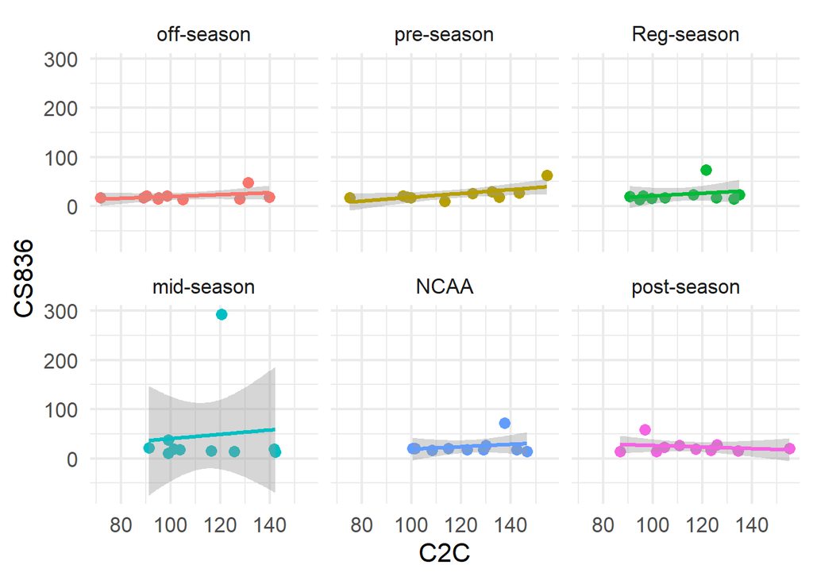

```r
ggplot(df_wide1, aes(x = C2C, y =CS836, color = time_point)) +
  geom_point(size = 3) +
  geom_smooth(method = "lm", se = TRUE, size = 1.1) +
  facet_wrap(~time_point)+
  theme_minimal(base_size = 16)+
  theme(legend.position = "none")
```

Figure 8: Comparing two biomarkers C2C and CS836 by different time points.

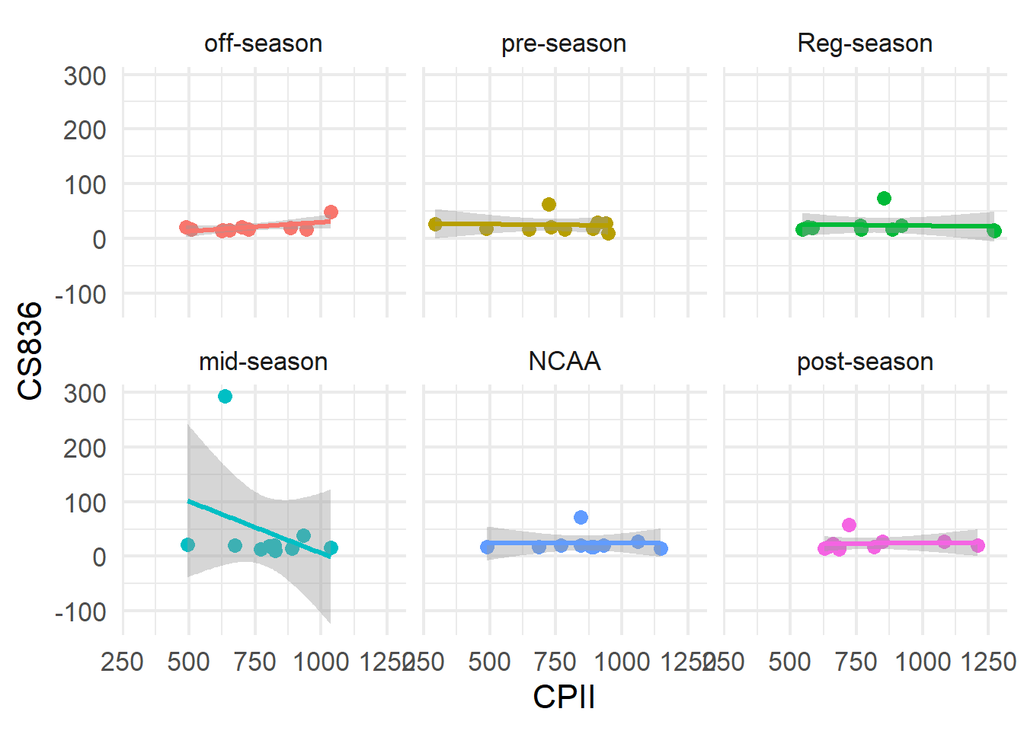

```r
library(ggplot2)

ggplot(df_wide1, aes(x = CPII, y = CS836, color = time_point)) +
  geom_point(size = 3) +
  geom_smooth(method = "lm", se = TRUE, size = 1.1) +
  facet_wrap(~time_point)+
  theme_minimal(base_size = 16)+
  theme(legend.position = "none")
```

Figure 9: Comparing two biomarkers CPII and CS836 by different time points.

4. Are biomarker values correlated with cumulative impact loads from 1 week prior to measurement?

```r
biomarker$impact_1w_scaled <- scale(biomarker$impact_1w)
md <- lmer(value ~ impact_1w_scaled + time_point + (1 | athlete_id), data = biomarker)
md1 <- lmer(value ~ impact_1w_scaled * biomarker + time_point + (1 | athlete_id), data = biomarker)
anova(md, md1)
```

[output not shown]

Table 4: linear mixed model summary table.

```r
tab_model(md1, show.re.var = FALSE)
```

|  | value |  |  |
| --- | --- | --- | --- |
| Predictors | Estimates | CI | p |
| (Intercept) | 97.34 | 34.91 – 159.77 | **0.003** |
| impact 1w scaled | -4.24 | -56.22 – 47.74 | 0.872 |
| biomarker [CPII] | 656.18 | 599.51 – 712.86 | **<0.001** |
| biomarker [CS836] | -88.45 | -145.12 – -31.78 | **0.003** |
| time point [pre-season] | -12.06 | -87.53 – 63.42 | 0.752 |
| time point [Reg-season] | 38.06 | -31.42 – 107.54 | 0.280 |
| time point [post-season] | 29.05 | -52.26 – 110.35 | 0.480 |
| impact 1w scaled × biomarker [CPII] | 6.56 | -49.96 – 63.08 | 0.818 |
| impact 1w scaled × biomarker [CS836] | -1.52 | -58.03 – 55.00 | 0.958 |
| ICC | 0.09 |  |  |
| N <sub>athlete_id</sub> | 10 |  |  |
| Observations | 111 |  |  |
| Marginal R<sup>2</sup> / Conditional R<sup>2</sup> | 0.871 / 0.883 |  |  |

The analysis indicates that cumulative impact load from the previous week is not significantly associated with biomarker levels, as shown by a non-significant coefficient (β = -4.24, 95% CI: [-56.22, 47.74], p = 0.872). Among the biomarkers, CPII levels are significantly higher compared to the reference biomarker C2C (β = 656.18, 95% CI: [599.51, 712.86], p < 0.001), while CS836 levels are significantly lower than C2C (β = -88.45, 95% CI: [-145.12, -31.78], p = 0.003). The interaction terms between impact load and biomarker type are not statistically significant, indicating that the relationship between impact load and biomarker levels does not differ across biomarkers. Additionally, seasonal time points (pre-season, regular season, and post-season) do not show significant effects on biomarker levels after accounting for other variables (Fig. 10).

There is no evidence that cumulative impact load from the previous week affects biomarker levels, either overall or differentially across biomarker types.

Figure 10: Cumulative 1 week impact load vs three biomarkers.

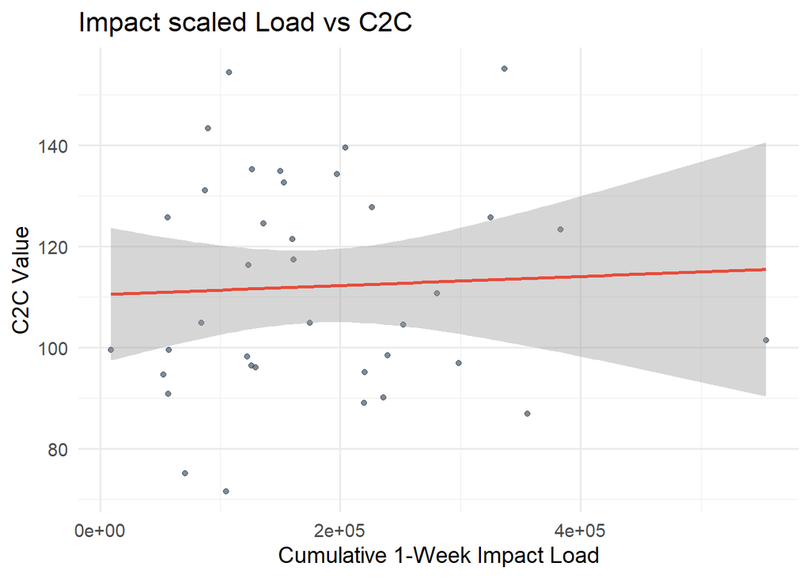

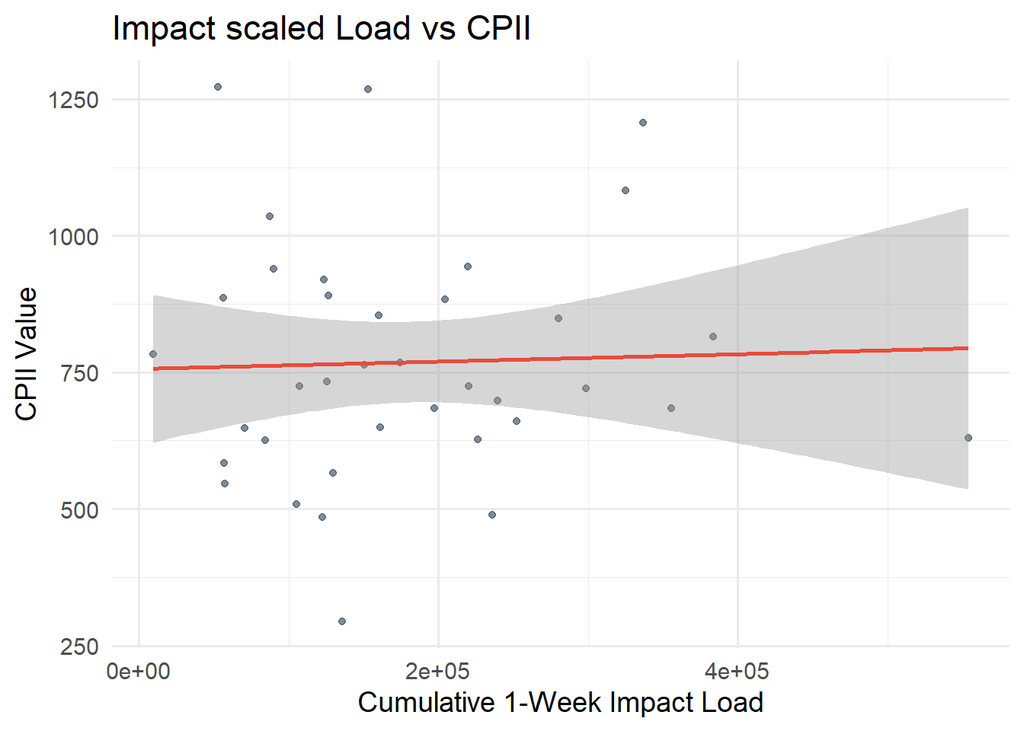

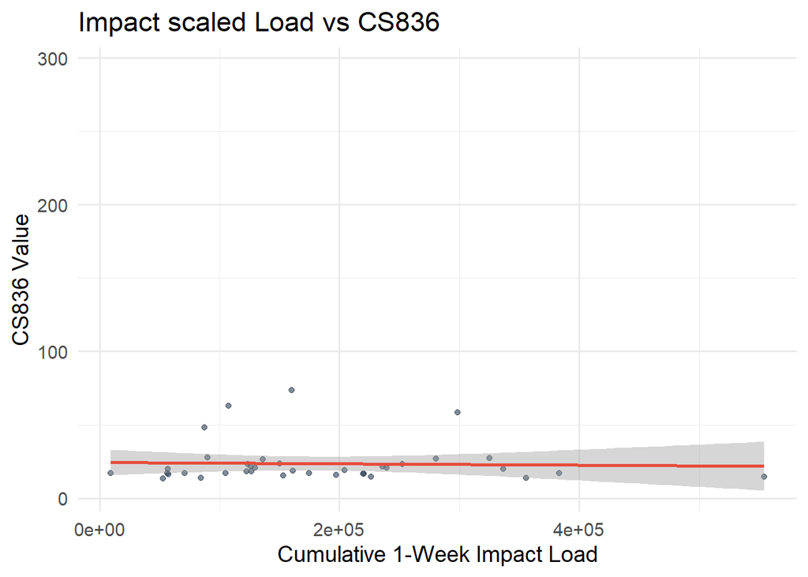

```r
biomarkers <- unique(biomarker$biomarker)
plots <- lapply(biomarkers, function(bio) {
  ggplot(biomarker %>% filter(biomarker == bio),
         aes(x = impact_1w, y = value)) +
    geom_point(color = "#2C3E50", alpha = 0.6) +
    geom_smooth(method = "lm", se = TRUE, color = "#E74C3C") +
    labs(title = paste("Impact scaled Load vs", bio),
         x = "Cumulative 1-Week Impact Load",
         y = paste(bio, "Value")) +
    theme_minimal(base_size = 14)
})

# Print the plots
for (p in plots) {
  print(p)
}
```

**Conclusions**

Correlation analyses revealed no significant repeated measures correlations between any pair of biomarkers. Additionally, regression modeling supported a significant positive relationship between C2C and CPII (p = 0.037), but no other pairwise associations were statistically meaningful. Likelihood ratio tests favored simpler models, suggesting interaction terms did not improve model fit.

**References**

Bakdash, J., & Marusich, L. (2024). rmcorr: Repeated measures correlation (Version 0.7.0) [R package]. https://CRAN.R-project.org/package=rmcorr

Bates, D., Mächler, M., Bolker, B., & Walker, S. (2015). Fitting linear mixed-effects models using lme4. Journal of Statistical Software, 67(1), 1–48. https://doi.org/10.18637/jss.v067.i01

Firke, S. (2024). janitor: Simple tools for examining and cleaning dirty data (Version 2.2.1) [R package]. https://CRAN.R-project.org/package=janitor

Kuznetsova, A., Brockhoff, P. B., & Christensen, R. H. B. (2017). lmerTest package: Tests in linear mixed effects models. Journal of Statistical Software, 82(13), 1–26. https://doi.org/10.18637/jss.v082.i13

Lüdecke, D. (2024). sjPlot: Data visualization for statistics in social science (Version 2.8.17) [R package]. https://CRAN.R-project.org/package=sjPlot

Sjoberg, D. D., Whiting, K., Curry, M., Lavery, J. A., & Larmarange, J. (2021). Reproducible summary tables with the gtsummary package. The R Journal, 13, 570–580. https://doi.org/10.32614/RJ-2021-053

Wickham, H. (2016). ggplot2: Elegant graphics for data analysis. Springer-Verlag.

Wickham, H., Averick, M., Bryan, J., Chang, W., McGowan, L. D., François, R., Grolemund, G., Hayes, A., Henry, L., Hester, J., Kuhn, M., Pedersen, T. L., Miller, E., Bache, S. M., Müller, K., Ooms, J., Robinson, D., Seidel, D. P., Spinu, V., … Yutani, H. (2019). Welcome to the tidyverse. Journal of Open Source Software, 4(43), 1686. https://doi.org/10.21105/joss.01686

Wickham, H., François, R., Henry, L., Müller, K., & Vaughan, D. (2023). dplyr: A grammar of data manipulation (Version 1.1.4) [R package]. https://CRAN.R-project.org/package=dplyr

Wickham, H., Vaughan, D., & Girlich, M. (2024). tidyr: Tidy messy data (Version 1.3.1) [R package]. https://CRAN.R-project.org/package=tidyr

Wilke, C. (2024). cowplot: Streamlined plot theme and plot annotations for ‘ggplot2’ (Version 1.1.3) [R package]. https://CRAN.R-project.org/package=cowplot